# homework_week05_day02

```r
library(tidyverse)
library(CodeClanData)
```

```r
qb_revenue_breakdown
```

| Product | Year | Revenue |
| --- | --- | --- |
| Trackers | 2019 | 8994 |
| Smart Watches | 2019 | 12003 |
| Accessories | 2019 | 5250 |
| Subscription Services | 2019 | 3750 |
| Trackers | 2018 | 8004 |
| Smart Watches | 2018 | 11000 |
| Accessories | 2018 | 4250 |
| Subscription Services | 2018 | 1005 |

```r
qb_monthly_sales
```

| Date | Cashflow | Amount |
| --- | --- | --- |
| 2019-07-01 | Kwikbit Unit 1 Sales | 601.74 |
| 2019-06-01 | Kwikbit Unit 1 Sales | 567.89 |
| 2019-05-01 | Kwikbit Unit 1 Sales | 536.00 |
| 2019-04-01 | Kwikbit Unit 1 Sales | 550.78 |
| 2019-03-01 | Kwikbit Unit 1 Sales | 526.03 |
| 2019-02-01 | Kwikbit Unit 1 Sales | 584.22 |
| 2019-01-01 | Kwikbit Unit 1 Sales | 530.76 |
| 2018-12-01 | Kwikbit Unit 1 Sales | 504.80 |
| 2018-11-01 | Kwikbit Unit 1 Sales | 513.67 |
| 2018-10-01 | Kwikbit Unit 1 Sales | 499.99 |

[output cut: 26 more lines]

```r
qb_competitors
```

| Company | Year | Revenue |
| --- | --- | --- |
| Competitor 1 | 2019 | 2216000 |
| Competitor 2 | 2019 | 1760000 |
| Competitor 3 | 2019 | 1455000 |
| Competitor 4 | 2019 | 1229000 |
| Competitor 1 | 2018 | 2144400 |
| Competitor 2 | 2018 | 1440000 |
| Competitor 3 | 2018 | 1555000 |
| Competitor 4 | 2018 | 987000 |
| Competitor 1 | 2017 | 1750000 |
| Competitor 2 | 2017 | 987000 |

[output cut: 10 more lines]

```r
qb_device_data
```

|  | device | id | hours | mins | counts |
| --- | --- | --- | --- | --- | --- |
| 361 | qikbit1 | person1 | 6 | 0 | 0 |
| 362 | qikbit1 | person1 | 6 | 1 | 0 |
| 363 | qikbit1 | person1 | 6 | 2 | 0 |
| 364 | qikbit1 | person1 | 6 | 3 | 0 |
| 365 | qikbit1 | person1 | 6 | 4 | 0 |
| 366 | qikbit1 | person1 | 6 | 5 | 0 |
| 367 | qikbit1 | person1 | 6 | 6 | 0 |
| 368 | qikbit1 | person1 | 6 | 7 | 0 |
| 369 | qikbit1 | person1 | 6 | 8 | 0 |
| 370 | qikbit1 | person1 | 6 | 9 | 0 |

[output cut: 990 more lines]

# 4.1 Part 1

1. Take the data in the dataset qb_revenue_breakdown and make a stacked bar chart showing the sources of revenue across the two years in the dataset.

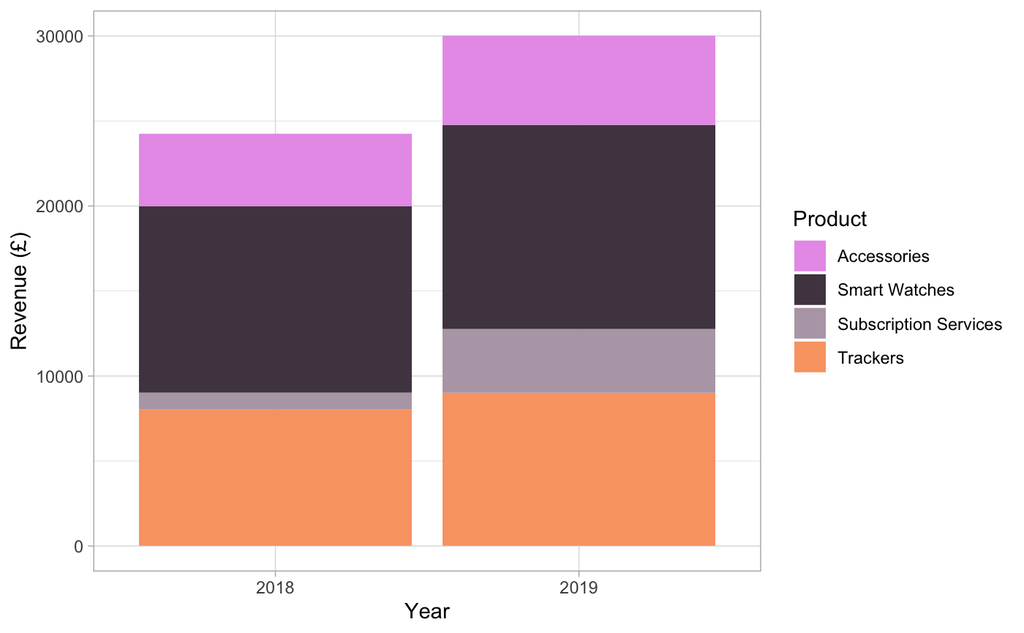

```r
col_scheme <- c("#E89FE9", "#50434F", "#B6A7B5", "#F9A472", "#BD7040")

ggplot(qb_revenue_breakdown) +
  aes(x = Year, y = Revenue, fill = Product) +
  theme_light() +
  labs(x = "Year", y = "Revenue (£)") +
  scale_fill_manual(values = col_scheme) +
  geom_col()
```

2. Make a line chart showing monthly sales of the “flagship product” - the KwikBit Unit1 - over the last year. This data is inside qb_monthly_sales, but you will need to use subset.

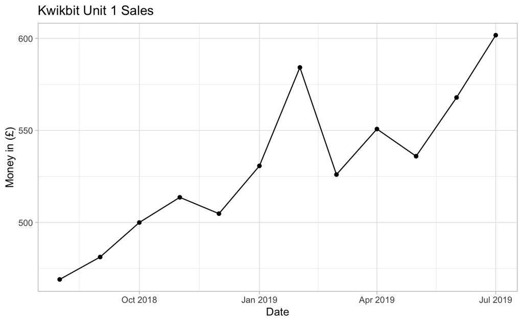

```r
flagship_product <- qb_monthly_sales %>%
  filter(Cashflow == "Kwikbit Unit 1 Sales")

ggplot(flagship_product) +
  aes(x = Date, y = Amount) +
  theme_light() +
  labs(x = "Date", y = "Money in (£)", title = "Kwikbit Unit 1 Sales") +
  geom_line() +
  geom_point()
```

```r
NA
```

3. Make a line chart showing monthly revenue and costs over the last year. This data is also in qb_monthly_sales.

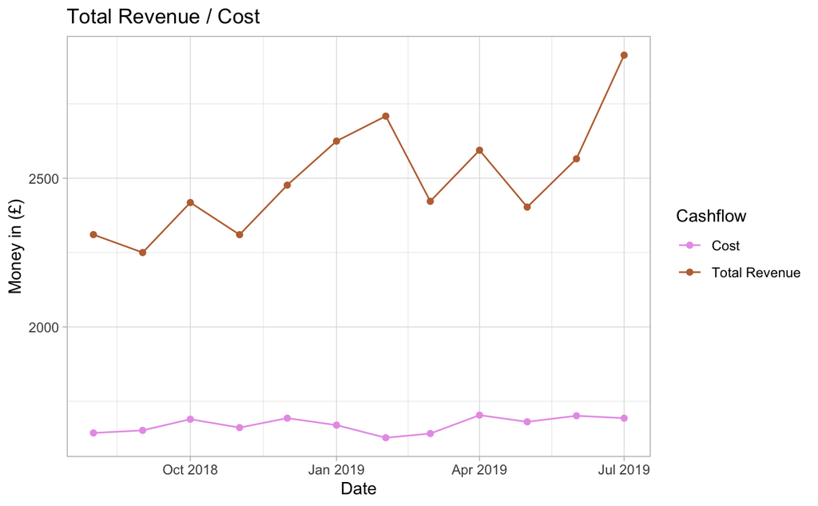

```r
cost_and_revenue <- qb_monthly_sales %>%
  filter(Cashflow != "Kwikbit Unit 1 Sales")

ggplot(cost_and_revenue) +
  aes(x = Date, y = Amount, colour = Cashflow) +
  scale_colour_manual(values = c("#E89FE9", "#BD7040")) +
  theme_light() +
  labs(x = "Date", y = "Money in (£)", title = "Total Revenue / Cost") +
  geom_line() +
  geom_point()
```

4. Show annual sales of personal fitness trackers over the last 5 years broken down by company as a ribbon plot (use geom_area). This data is in qb_competitors.

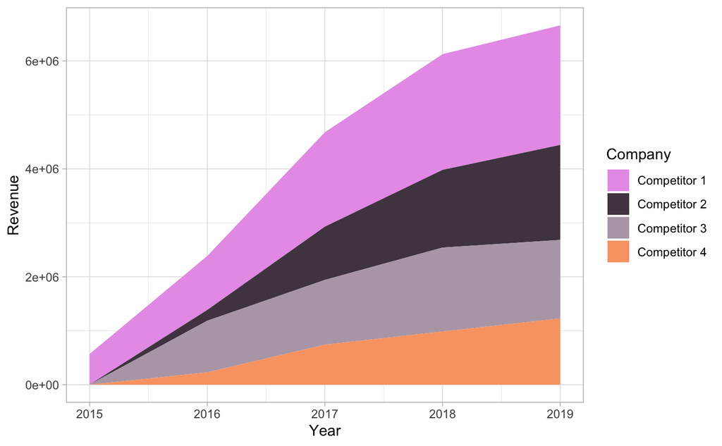

```r
ggplot(qb_competitors) +
  aes(x = Year, y = Revenue, fill = Company) +
  scale_fill_manual(values = col_scheme) +
  theme_light() +
  geom_area()
```

```r
NA
```

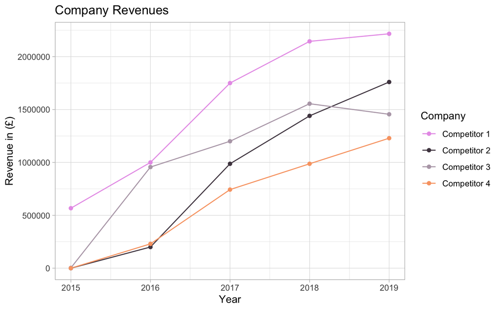

```r
ggplot(qb_competitors) +
  aes(x = Year, y = Revenue, colour = Company) +
  scale_colour_manual(values = col_scheme) +
  theme_light() +
  labs(x = "Year", y = "Revenue in (£)", title = "Company Revenues") +
  geom_line() +
  geom_point()
```

6. Now the company wants to compare the number of steps that their device counts vs. their competitors. Make a line graph of the number of steps throughout time, and use faceting to compare between individuals and people. Data is in qb_device_data.

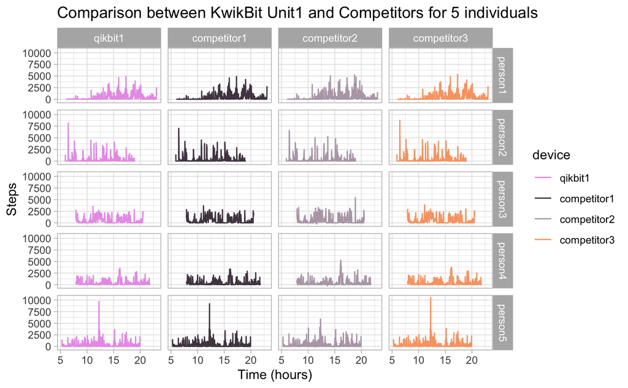

```r
qb_device_data <-
mutate(qb_device_data, decimal_hour = hours + (mins/60))

ggplot(qb_device_data) +
  aes(x = decimal_hour, y = counts, colour = device) +
  geom_line() +
  scale_x_continuous("Time (hours)") +
  scale_y_continuous("Steps") +
  facet_grid(id ~ device) +
  scale_colour_manual(values = col_scheme) +
  theme_light() +
  ggtitle("Comparison between KwikBit Unit1 and Competitors for 5 individuals")
```

```r
NA
```